# Nobel Prize Winners Analysis 1901 - 2023

# Contexte

Since 1901, the Nobel Prize has been awarded annually to recognize groundbreaking achievements in Physics, Chemistry, Physiology or Medicine, Literature, and Peace. It stands as one of the most prestigious honors, celebrating individuals and organizations who have conferred the “greatest benefit on mankind.” In 1968, a prize in Economic Sciences was established in memory of Alfred Nobel. This analysis explores the rich history of the Nobel laureates from 1901 to 2023, delving into the trends, demographics, and stories hidden within this remarkable dataset. We will investigate the distribution of prizes across different fields and decades, the evolving age and gender of the laureates, and the geographical concentration of these monumental achievements.

# Loading Libraries and Data

```r
library(tidyverse)
library(ggthemes)
library(DT)

theme_set(theme_minimal(base_size = 14))
nobel_raw <- read_csv("nobel_laureates_data.csv")
```

# Data Pre-processing

```r
# A function to extract the year using stringr
extract_year <- function(date_string) {
  str_extract(date_string, "\\d{4}")
}

nobel <- nobel_raw %>%
  rename(prize_year = year) %>%
  mutate(
    birth_year = as.numeric(extract_year(born)),
    age = if_else(gender != "org", prize_year - birth_year, NA_real_),
    category = str_to_sentence(category),
    gender = str_to_sentence(gender),
    decade = 10 * floor(prize_year / 10)
  )

glimpse(nobel)
```

```
## Rows: 1,000
## Columns: 19
## $ prize_year          <dbl> 2023, 2023, 2023, 2023, 2023, 2023, 2023, 2023, 20…
## $ category            <chr> "Medicine", "Economics", "Peace", "Literature", "C…
## $ motivation          <chr> "for their discoveries concerning nucleoside base …
## $ prizeShare          <dbl> 2, 1, 1, 1, 3, 3, 3, 3, 3, 3, 2, 3, 1, 3, 3, 3, 3,…
## $ laureateID          <dbl> 1024, 1034, 1033, 1032, 1031, 1030, 1029, 1028, 10…
## $ fullName            <chr> "Katalin Kariko", "Claudia Goldin", "Narges Mohamm…
## $ gender              <chr> "Female", "Female", "Female", "Male", "Male", "Mal…
## $ born                <chr> "17-01-1955", "1946-00-00", "21-04-1972", "29-09-1…
## $ bornCountry         <chr> "Hungary", "USA", "Iran", "Norway", "Russia", "USA…
## $ bornCity            <chr> "Szolnok", "New York NY", "Zanjan", "Haugesund", N…
## $ died                <chr> "0000-00-00", "0000-00-00", "0000-00-00", "0000-00…
## $ diedCountry         <chr> NA, NA, NA, NA, NA, NA, NA, NA, NA, NA, NA, NA, NA…
## $ diedCity            <chr> NA, NA, NA, NA, NA, NA, NA, NA, NA, NA, NA, NA, NA…
## $ organizationName    <chr> "Szeged University", "Harvard University", NA, NA,…
## $ organizationCountry <chr> "Hungary", "USA", NA, NA, "USA", "USA", "USA", "Sw…
## $ organizationCity    <chr> "Szeged", "Cambridge MA", NA, NA, "New York NY", "…
## $ birth_year          <dbl> 1955, 1946, 1972, 1959, 1945, 1943, 1961, 1958, 19…
## $ age                 <dbl> 68, 77, 51, 64, 78, 80, 62, 65, 61, 82, 64, 75, 67…
## $ decade              <dbl> 2020, 2020, 2020, 2020, 2020, 2020, 2020, 2020, 20…
```

# The Growth of Nobel Prizes Over Time

This first analysis examines how the number of Nobel laureates has changed each decade across the different prize categories.

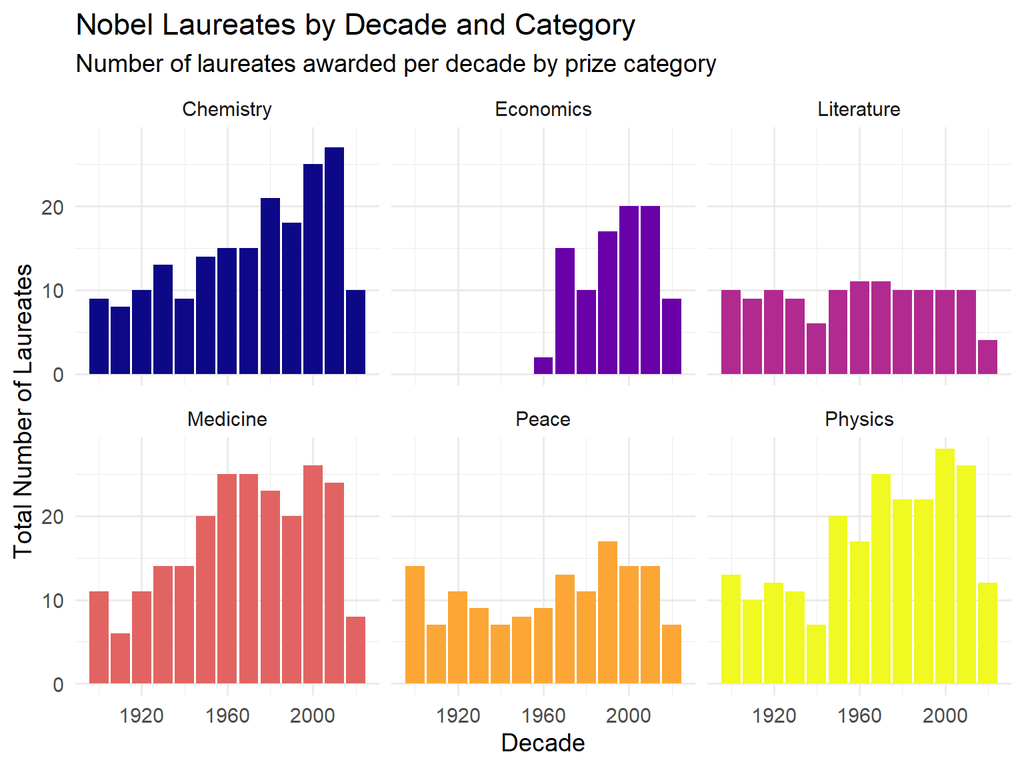

```r
nobel %>%
  count(decade, category) %>%
  ggplot(aes(x = decade, y = n, fill = category)) +
  geom_col(show.legend = FALSE) +
  facet_wrap(~category) +
  scale_fill_viridis_d(option = "C") +
  labs(
    title = "Nobel Laureates by Decade and Category",
    subtitle = "Number of laureates awarded per decade by prize category",
    x = "Decade",
    y = "Total Number of Laureates"
  )
```

The charts reveal several interesting trends. The number of laureates, particularly in Physics, Chemistry, and Medicine, grew steadily, peaking in the late 20th and early 21st centuries. This reflects the increasing collaboration in scientific research, where prizes are now frequently shared among two or three recipients. The Peace prize shows high volatility, with noticeable dips during World War I (1910s) and World War II (1940s). The Economics prize begins in the late 1960s, as expected. Literature has remained remarkably consistent, typically awarded to a single individual each year.

## The Rise of Shared Prizes

The previous chart showed the total number of laureates. But are more prizes being shared now than before. By calculating the average number of winners per prize each year, we can see a clear trend.

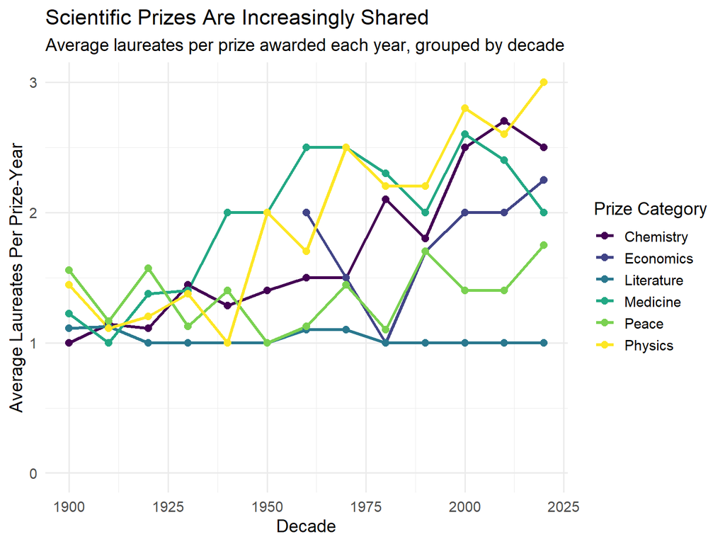

```r
nobel %>%
  group_by(decade, category) %>%
  summarise(
    total_laureates = n(),
    distinct_years = n_distinct(prize_year),
    avg_laureates_per_year = total_laureates / distinct_years,
    .groups = "drop"
  ) %>%
  ggplot(aes(x = decade, y = avg_laureates_per_year, color = category)) +
  geom_line(linewidth = 1.2) +
  geom_point(size = 2.5) +
  scale_color_viridis_d(name = "Prize Category", option = "D") +
  expand_limits(y = 0) +
  labs(
    title = "Scientific Prizes Are Increasingly Shared",
    subtitle = "Average laureates per prize awarded each year, grouped by decade",
    x = "Decade",
    y = "Average Laureates Per Prize-Year"
  )
```

## The Exclusive Club of Multiple Winners

A very small number of individuals and organizations have received the Nobel Prize more than once. The table below highlights these exceptional cases.

```r
nobel %>%
  mutate(Laureate_Type = if_else(gender %in% c("Female", "Male"), "Individual", "Organization")) %>%
  group_by(fullName, Laureate_Type) %>%
  summarise(
    times_won = n(),
    categories = paste(unique(category), collapse = " & "),
    years = paste(sort(unique(prize_year)), collapse = " & "),
    .groups = "drop"
  ) %>%
  filter(times_won > 1) %>%
  arrange(desc(times_won), fullName) %>%
  DT::datatable(
    class = 'cell-border stripe',
    rownames = FALSE,
    options = list(
      scrollX = TRUE,
      pageLength = 7
    ),
    caption = "Individuals and Organizations Awarded the Nobel Prize More Than Once"
  )
```

| fullName | Laureate_Type | times_won | categories | years |
| --- | --- | --- | --- | --- |
| International Committee of the Red Cross | Organization | 3 | Peace | 1917 &amp; 1944 &amp; 1963 |
| Barry Sharpless | Individual | 2 | Chemistry | 2001 &amp; 2022 |
| Frederick Sanger | Individual | 2 | Chemistry | 1958 &amp; 1980 |
| John Bardeen | Individual | 2 | Physics | 1956 &amp; 1972 |
| Linus Pauling | Individual | 2 | Peace &amp; Chemistry | 1954 &amp; 1962 |
| Marie Curie | Individual | 2 | Chemistry &amp; Physics | 1903 &amp; 1911 |
| Office of the United Nations High Commissioner for Refugees | Organization | 2 | Peace | 1954 &amp; 1981 |

# Gender Disparity in Nobel Prizes

The history of the Nobel Prize is also a story of significant gender imbalance. While this has slowly started to change, men remain the vast majority of laureates.

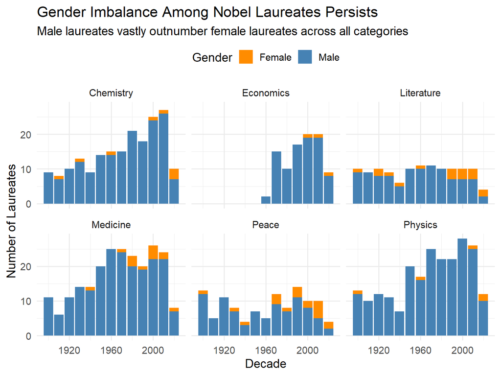

```r
nobel %>%
  filter(gender %in% c("Female", "Male")) %>%
  count(decade, category, gender) %>%
  ggplot(aes(x = decade, y = n, fill = gender)) +
  geom_col() +
  facet_wrap(~category) +
  scale_fill_manual(values = c("Female" = "darkorange", "Male" = "steelblue")) +
  labs(
    title = "Gender Imbalance Among Nobel Laureates Persists",
    subtitle = "Male laureates vastly outnumber female laureates across all categories",
    x = "Decade",
    y = "Number of Laureates",
    fill = "Gender"
  ) +
  theme(legend.position = "top")
```

## Pioneering Women: The First Female Laureates

The table below celebrates the first woman to win the Nobel Prize in each category, honoring their trailblazing achievements.

```r
nobel %>%
  filter(gender == "Female") %>%
  group_by(category) %>%
  slice_min(order_by = prize_year, n = 1) %>%
  select(fullName, prize_year, category, age) %>%
  arrange(prize_year) %>%
  DT::datatable(
    class = 'cell-border stripe',
    rownames = FALSE,
    options = list(
      scrollX = TRUE,
      pageLength = 6
    ))
```

| fullName | prize_year | category | age |
| --- | --- | --- | --- |
| Marie Curie | 1903 | Physics | 36 |
| Bertha von Suttner | 1905 | Peace | 62 |
| Selma Lagerlof | 1909 | Literature | 51 |
| Marie Curie | 1911 | Chemistry | 44 |
| Gerty Cori | 1947 | Medicine | 51 |
| Elinor Ostrom | 2009 | Economics | 76 |

# The Aging of Genius: Laureate Ages Over Time

Is there an age at which one is most likely to receive a Nobel Prize? And has this changed over the years?

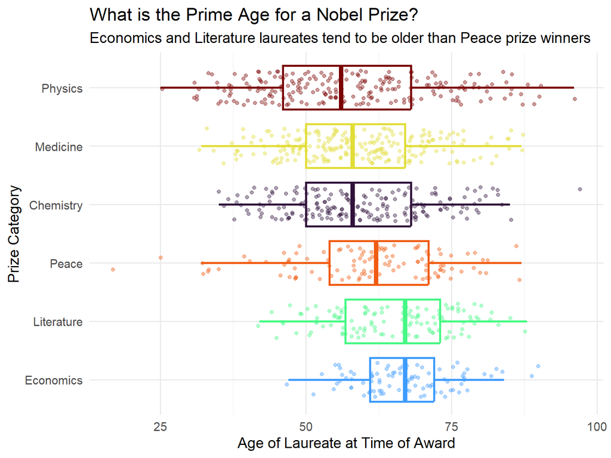

```r
nobel %>%
  filter(!is.na(age)) %>%
  ggplot(aes(x = fct_reorder(category, age, median, .desc = TRUE), y = age, color = category)) +
  geom_boxplot(show.legend = FALSE, outlier.shape = NA, size = 1) +
  geom_jitter(show.legend = FALSE, alpha = 0.4, width = 0.3) +
  coord_flip() +
  scale_color_viridis_d(option = "H") +
  labs(
    title = "What is the Prime Age for a Nobel Prize?",
    subtitle = "Economics and Literature laureates tend to be older than Peace prize winners",
    x = "Prize Category",
    y = "Age of Laureate at Time of Award"
  )
```

The plot shows that Economics laureates have the highest median age, often receiving the prize for work done decades earlier. In contrast, the Peace prize is frequently awarded to individuals for more contemporary efforts, resulting in a younger median age. Malala Yousafzai, who received the Peace prize at age 17, is a notable outlier.

## Are Nobel Laureates Getting Older?

By plotting the average age of laureates over the decades, we can see a distinct upward trend in the scientific fields.

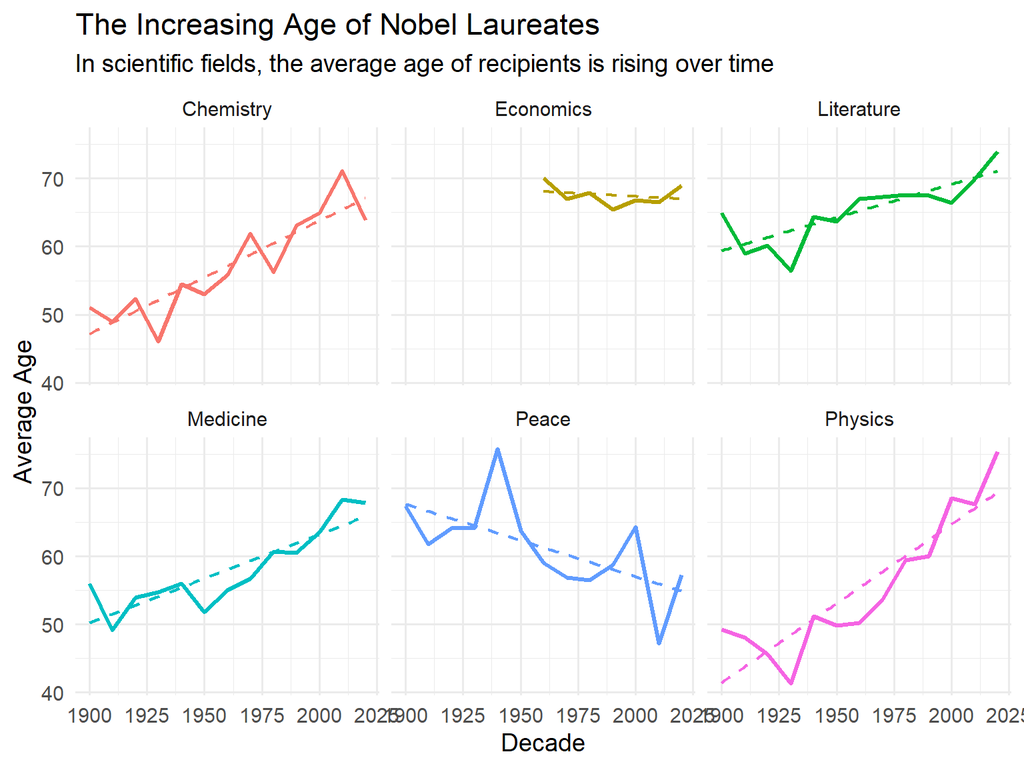

```r
nobel %>%
  filter(!is.na(age)) %>%
  group_by(decade, category) %>%
  summarise(avg_age = mean(age), .groups = "drop") %>%
  ggplot(aes(x = decade, y = avg_age, color = category)) +
  geom_line(linewidth = 1.2) +
  geom_smooth(method = "lm", se = FALSE, linetype = "dashed", linewidth = 0.8) +
  facet_wrap(~category) +
  theme(legend.position = "none") +
  labs(
    title = "The Increasing Age of Nobel Laureates",
    subtitle = "In scientific fields, the average age of recipients is rising over time",
    x = "Decade",
    y = "Average Age"
  )
```

There is a clear and significant trend of laureates in Physics, Chemistry, and Medicine getting older. This could be due to several factors, including the increasing complexity of these fields, the time it takes for a discovery’s impact to be recognized, and longer life expectancies.

# A Geography of Excellence

Finally, where do Nobel laureates come from? This analysis explores the birth countries of the winners to understand the geographical distribution of Nobel prizes.

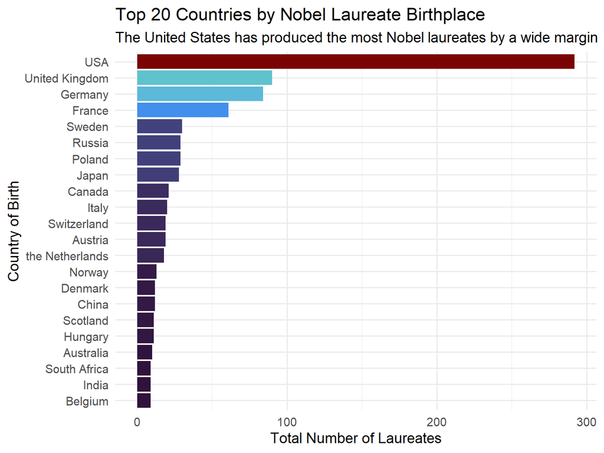

```r
nobel %>%
  filter(!is.na(bornCountry)) %>%
  mutate(country = fct_lump_n(bornCountry, n = 20)) %>%
  filter(country != "Other") %>%
  count(country, sort = TRUE) %>%
  ggplot(aes(x = n, y = fct_reorder(country, n), fill = n)) +
  geom_col() +
  scale_fill_viridis_c(guide = "none", option = "H") +
  labs(
    title = "Top 20 Countries by Nobel Laureate Birthplace",
    subtitle = "The United States has produced the most Nobel laureates by a wide margin",
    x = "Total Number of Laureates",
    y = "Country of Birth"
  )
```

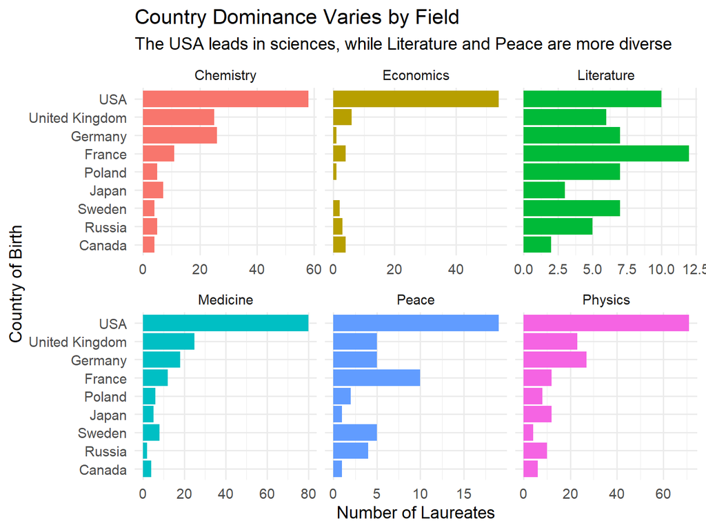

```r
nobel %>%
  filter(!is.na(bornCountry)) %>%
  mutate(country = fct_lump_n(bornCountry, n = 9)) %>%
  count(country, category) %>%
  filter(country != "Other") %>%
  ggplot(aes(x = n, y = fct_reorder(country, n), fill = category)) +
  geom_col(show.legend = FALSE) +
  facet_wrap(~category, scales = "free_x") +
  labs(
    title = "Country Dominance Varies by Field",
    subtitle = "The USA leads in sciences, while Literature and Peace are more diverse",
    x = "Number of Laureates",
    y = "Country of Birth"
  )
```

The charts starkly illustrate the dominance of laureates born in the United States and Western Europe. This is especially pronounced in the scientific fields and Economics. In contrast, the Literature and Peace prizes show a more globally diverse set of winners, reflecting their different criteria and scope.

## Geographic Trends Over Time

Has the dominance of the United States and Europe been constant? By plotting the proportion of Nobel laureates from top countries over the decades, we can see how the global landscape of science and culture has evolved.

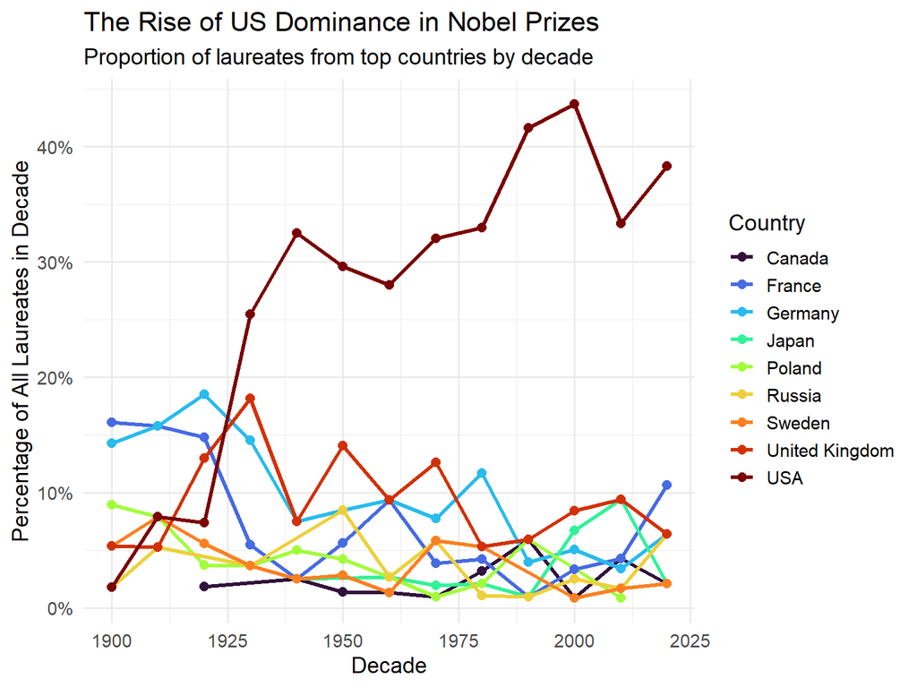

```r
# We'll focus on the top 6 countries to keep the plot readable
top_countries <- nobel %>%
  filter(!is.na(bornCountry)) %>%
  count(bornCountry, sort = TRUE) %>%
  head(9) %>%
  pull(bornCountry)

nobel %>%
  filter(!is.na(bornCountry)) %>%
  count(decade, bornCountry) %>%
  group_by(decade) %>%
  mutate(proportion = n / sum(n)) %>%
  ungroup() %>%
  filter(bornCountry %in% top_countries) %>%
  ggplot(aes(x = decade, y = proportion, color = bornCountry)) +
  geom_line(linewidth = 1.2) +
  geom_point(size = 2.5) +
  scale_y_continuous(labels = scales::percent) +
  scale_color_viridis_d(name = "Country", option = "H") +
  labs(
    title = "The Rise of US Dominance in Nobel Prizes",
    subtitle = "Proportion of laureates from top countries by decade",
    x = "Decade",
    y = "Percentage of All Laureates in Decade"
  )
```

# The Powerhouses of Research: Top Institutions

While the birth country of a laureate is interesting, the institution where they conducted their prize-winning research is arguably more important. This analysis identifies the universities and organizations that have fostered the most Nobel laureates.

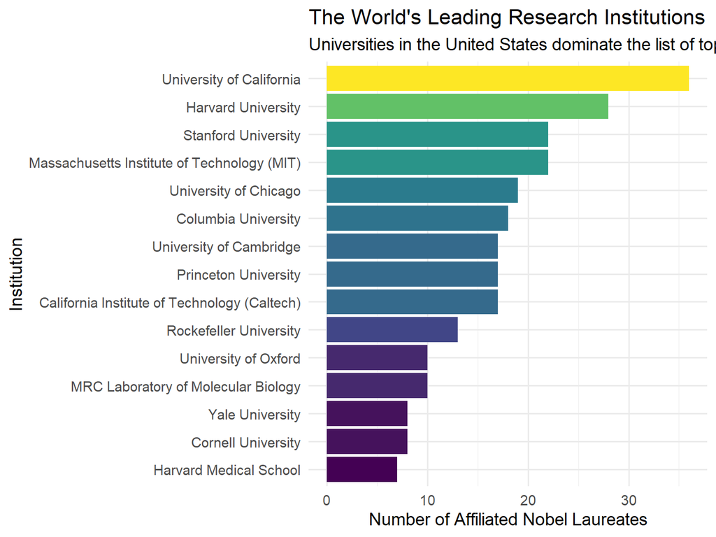

```r
nobel %>%
  filter(!is.na(organizationName)) %>%
  separate_rows(organizationName, sep = ",| and ") %>%
  mutate(organizationName = str_trim(organizationName)) %>%
  count(organizationName, sort = TRUE) %>%
  head(15) %>%
  ggplot(aes(x = n, y = fct_reorder(organizationName, n), fill = n)) +
  geom_col() +
  scale_fill_viridis_c(guide = 'none') +
  labs(
    title = "The World's Leading Research Institutions",
    subtitle = "Universities in the United States dominate the list of top Nobel-affiliated organizations",
    x = "Number of Affiliated Nobel Laureates",
    y = "Institution"
  )
```